# FibroTarget-Liver Executive Summary

Human liver fibrosis single-cell analysis, validation, and target prioritization

## Executive View

FibroTarget-Liver is a reproducible single-cell workflow for human liver fibrosis target discovery. It starts from the public GSE136103 count matrices, runs a Seurat-based human liver analysis, validates priority candidates in MASH/NAFLD and preclinical context datasets, and produces ranked biomarker and target candidates with transparent evidence.

**Primary analysis question:** in human cirrhotic liver, which cell-state-linked genes are credible as diagnostic biomarkers, pharmacodynamic biomarkers, therapeutic hypotheses, or future validation markers?

**Main biological result:** fibrosis signal is concentrated in a scar niche made of activated stromal/HSC/myofibroblast-like cells, scar-associated endothelial programs, and macrophage injury or repair states.

**Main translational result:** the strongest fibrosis markers are not automatically the best drug targets.

| Use case | Best-supported candidates | Interpretation |
| --- | --- | --- |
| Fibrosis burden and pharmacodynamic readout | COL1A1, COL3A1, TIMP1 | Strong scar signal; collagens are endpoints, not direct targets |
| Secreted biomarker | SMOC2, TIMP1 | Practical assay potential; TIMP1 needs specificity checks |
| Scar vascular niche | ACKR1, PLVAP | Strong tissue-state markers; targeting requires vascular safety work |
| Therapeutic hypothesis | PDGFRA, PDGFRB | Druggable stromal receptor biology; safety window is the key question |
| Macrophage validation queue | TREM2, CD9, SPP1, GPNMB | Important disease biology; needs macrophage atlas and spatial validation |

**Most useful next step:** spatial and protein validation. More ranking will not answer the central translational questions. The next decision points are where the proteins localize, whether the signal is conserved in disease models, and whether perturbing the candidate changes a fibrosis-relevant phenotype.

**What was built beyond the analysis:** an interactive Shiny dashboard and a standalone Nextflow demo that runs locally and maps to AWS.

## Analysis Outcomes

| Requested outcome | Status | Evidence |
| --- | --- | --- |
| Curate and summarize dataset and metadata | Complete | GEO manifest, sample inclusion/exclusion table, QC summaries |
| Perform QC and preprocessing with choices explained | Complete | Seurat workflow, QC tables, method walkthrough |
| Annotate major liver cell types and validate disease compartments | Complete | marker scores, dot plot, refined reference labels |
| Identify fibrosis/cirrhosis-associated genes or cell states | Complete | cell-level screen plus donor-level pseudobulk DE |
| Perform pathway or mechanism analysis | Complete | Hallmark/EnrichR-style enrichment plus pathfindR Reactome active-subnetwork analysis from pseudobulk DE |
| Build AI/ML-assisted or rule-based prioritization score | Complete | transparent scoring model with positive evidence and penalties |
| Produce ranked 10-20 candidates | Complete | ranked translational candidate table and dashboard filters |
| Explain translational relevance | Complete | diagnostic, pharmacodynamic, therapeutic, and validation categories |
| Reproducibility | Complete | Makefile, renv, Dockerfile, validation checks, Nextflow demo |

## Dataset Curation

The primary dataset is **GSE136103**, a human liver scRNA-seq study of healthy and cirrhotic tissue. The pipeline builds a sample manifest from the GEO archive and labels each library by species, tissue, disease state, donor, and fraction.

Only human liver libraries are used for the primary discovery contrast. Blood and mouse libraries are excluded from the main contrast, then brought back as validation modules.

| disease_state | compartment_call | cells | libraries | donors |
| --- | --- | --- | --- | --- |
| cirrhotic | endothelial | 5526 | 9 | 5 |
| cirrhotic | macrophage_monocyte | 11953 | 9 | 5 |
| cirrhotic | mesenchymal_HSC_myofibroblast | 783 | 9 | 5 |
| cirrhotic | other_or_unresolved | 7472 | 9 | 5 |
| healthy | endothelial | 3314 | 11 | 5 |
| healthy | macrophage_monocyte | 14897 | 11 | 5 |
| healthy | mesenchymal_HSC_myofibroblast | 2237 | 11 | 5 |
| healthy | other_or_unresolved | 14585 | 11 | 5 |

Why this matters: if blood or mouse libraries are mixed into the main model, the largest signal may be tissue or species, not liver fibrosis. Keeping them separate makes the biological question cleaner. The blood libraries are used later to flag broad circulating expression and tissue-specificity concerns, while the mouse libraries are used as an ortholog conservation and preclinical directionality screen.

## QC And Preprocessing

The local analysis uses Seurat. Each library is loaded from GEO matrices, converted to a Seurat object, annotated with curated metadata, merged, filtered, normalized, scaled, clustered, and visualized with UMAP.

QC metrics reviewed:

- **Detected genes per cell (`nFeature_RNA`)**: low values usually indicate empty droplets or poor capture.
- **UMIs per cell (`nCount_RNA`)**: very high values can indicate doublets, but high RNA content can also be real in large or activated cells.
- **Mitochondrial percentage**: high values can indicate damaged cells. In scRNA-seq, 15-25 percent is a common review range; this compact run uses 25 percent so obvious damaged cells are removed while stressed disease-relevant liver cells are not filtered too aggressively.
- **Ribosomal percentage**: helps flag stressed or technically biased libraries; not used as a hard filter because ribosomal signal can reflect dissociation stress, library composition, or real high-translation cell states.
- **Hemoglobin percentage**: helps flag blood/RBC ambient RNA contamination; reviewed but not used as a hard filter because liver samples can contain vascular and blood-associated signal that should be judged by sample and cell context.
- **Complexity (`log10 genes per UMI`)**: low complexity can mark poor-quality cells or ambient-dominated droplets.

| metric | threshold_or_action | used_for_filtering | reason |
| --- | --- | --- | --- |
| Detected genes per cell | >=200 | TRUE | Removes low-complexity droplets while retaining stressed disease-relevant cells. |
| Mitochondrial percent | <=25% | TRUE | Typical scRNA-seq filters often review 15-25% mitochondrial reads. This run uses 25% to remove likely damaged cells while retaining diseased or stressed liver cells with real injury biology. |
| UMI count | reviewed by library; no hard upper cutoff in compact run | FALSE | High UMI cells can be doublets, but liver cell types differ in RNA content; hard filtering could remove large or active cells. |
| Ribosomal percent | reviewed by library; no hard cutoff | FALSE | High ribosomal signal can reflect cell state or technical stress and is interpreted with other metrics. |
| Hemoglobin percent | reviewed by library; no hard cutoff | FALSE | Flags erythrocyte/RBC ambient RNA contamination without removing liver cells solely on this metric. |
| log10 genes per UMI | reviewed by library; no hard cutoff | FALSE | Low complexity can indicate poor-quality cells; used as a diagnostic metric rather than a blind filter. |
| Doublet/ambient RNA | not removed in compact run; recommended production module | FALSE | Mixed marker states in scar tissue can be real niches or artifacts, so production filtering should combine algorithmic scores with marker review. |

Here, “stressed biology” means real injury-response states expected in fibrotic liver, such as hypoxic, inflamed, metabolically stressed, or activated cells. The mitochondrial threshold is therefore deliberately permissive enough to keep those diseased cells while still removing cells most likely to be technically compromised.

| total_cells_before_filter | cells_after_filter | cells_removed_low_genes | cells_removed_high_mito | cells_removed_any_filter | pct_retained |
| --- | --- | --- | --- | --- | --- |
| 61900 | 60767 | 3 | 1133 | 1133 | 98.16963 |

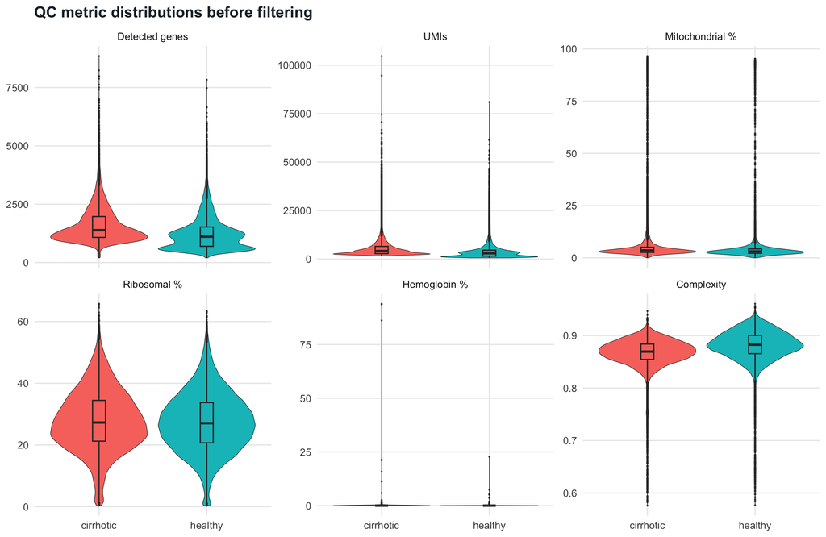

Figure: QC distributions across key metrics. The plot shows why the compact run uses conservative hard filters for low genes and high mitochondrial percentage, while treating ribosomal, hemoglobin, UMI count, and complexity as review metrics rather than automatic exclusion rules.

Key filtering choices:

- minimum detected genes: 200
- mitochondrial cutoff: 25 percent
- variable genes: 3,000
- graph and UMAP dimensions: first 20 PCs
- clustering resolution: 0.5

The 200-gene cutoff removes low-complexity droplets. The 25 percent mitochondrial cutoff is deliberately conservative because fibrotic liver contains stressed cells that may be biologically meaningful. In practice, this means the threshold was chosen to include diseased cells with moderate mitochondrial signal, not only pristine healthy cells. Ribosomal percentage, hemoglobin percentage, UMI count, and complexity were reviewed and recorded, but not used as hard filters because each can reflect either artifact or biology depending on cell type, sample quality, vascular contamination, and tissue state.

UMAP is used rather than t-SNE because it is fast, standard in Seurat, and useful for inspecting continuous activation states. UMAP is only a visualization. Inference comes from marker validation, donor-level DE, pathway analysis, and external validation.

Core files:

- Seurat preprocessing workflow
- QC by library
- QC by library and compartment after filtering
- QC metric summary
- QC filter summary
- QC decision log

## Cell Annotation

These three compartments were prioritized because they cover the core fibrotic niche: scar-producing stromal/HSC-myofibroblast cells, inflammatory and repair macrophage states, and remodeled endothelial cells that shape vascular leak, immune trafficking, and scar-associated microenvironments. A short primer is included in docs/biology_primer_liver_fibrosis.md.

The required disease-relevant compartments were identified with marker programs and then checked against the published Ramachandran annotation object.

The first-pass compartment labels are generated by a simple marker-scoring rule built on Seurat-normalized expression. Technically, the workflow takes the normalized RNA `data` layer, averages the expression of each marker set per cell, compares the mesenchymal, macrophage, and endothelial scores, and assigns the cell to the highest-scoring required compartment only if that score is above 0.25. Cells without a clear marker-program signal remain `other_or_unresolved`. This rule is implemented in workflow/03_compact_analysis.R using the helper `marker_score()` in src/R/utils.R.

| Label in outputs | Meaning | Markers |
| --- | --- | --- |
| `mesenchymal_HSC_myofibroblast` | activated stromal compartment | COL1A1, COL3A1, ACTA2, TAGLN, PDGFRA, PDGFRB, LUM, DCN, RGS5 |
| `macrophage_monocyte` | immune remodeling compartment | TREM2, CD9, SPP1, GPNMB, LST1, C1QA, C1QB, C1QC |
| `endothelial` | vascular compartment | ACKR1, PLVAP, VWF, PECAM1, KDR, RAMP2, ENG |
| `other_or_unresolved` | not confidently assigned to the required compartments | mixed or low marker support |

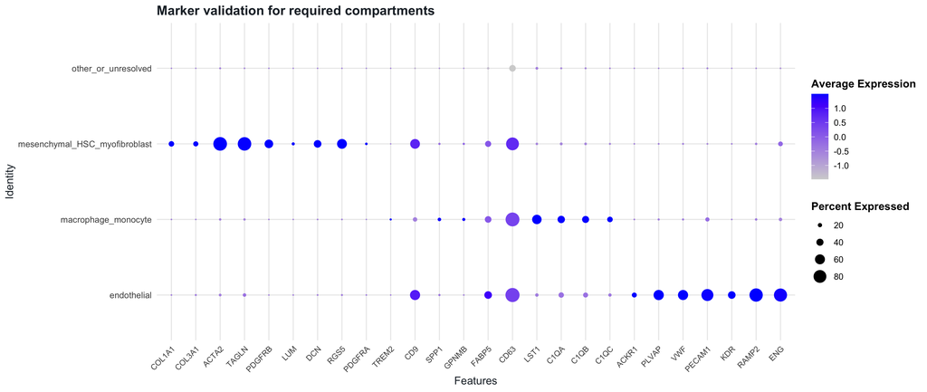

Figure: Required-compartment marker dot plot. Dot size is the fraction of cells expressing the marker. Color is average normalized expression. The goal is not a single perfect marker, but a coherent marker program within each compartment.

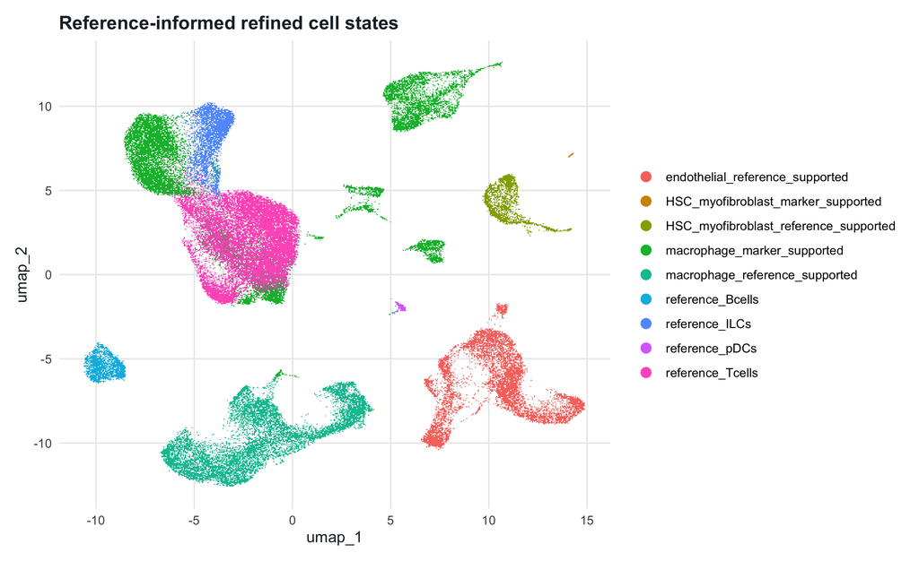

Figure: Refined UMAP colored by marker-supported and reference-supported labels. Each point is one cell. Nearby cells have similar transcriptomes in the reduced-dimensional Seurat space. Overlap between labels often reflects shared biology, such as stromal activation or immune remodeling, but it can also reflect broad labels, transitional states, or imperfect reference transfer.

How to read the marker dot plot:

- Dot size shows the fraction of cells in that output label expressing the marker.
- Color intensity shows average normalized expression.
- A convincing compartment should show several expected markers together, not one isolated marker.

How to read the refined UMAP:

- Each point is a cell embedded by transcriptomic similarity.
- Labels ending in `reference_supported` are clusters whose marker profile was supported by the published Ramachandran annotation layer.
- Overlapping cells do not mean the labels are wrong. In liver fibrosis, overlap can reflect continuous activation programs, shared wound-healing genes, or closely related scar-niche states.
- Discrepant labels are handled conservatively. If marker scoring suggests one compartment but the published reference points elsewhere, the label is refined only when marker biology, cluster context, and reference support agree. Otherwise the state is kept broad or unresolved.
- The UMAP is used for visual inspection and biological sanity checks, not for statistical testing.

The published Seurat object was used as an annotation reference, not as the primary analysis input. The pipeline rebuilds the analysis from GEO matrices, then uses `annotation_lineage` and `annotation_indepth` from the published object to refine broad cluster interpretation. This adds expert context while preserving raw-count reproducibility.

Biological readout: the UMAP supports a scar-niche interpretation rather than a single isolated marker story. Stromal/HSC-like, endothelial, and macrophage states separate enough to recover the required compartments, but they also sit within a broader disease-remodeling landscape. That is expected in cirrhosis, where matrix deposition, immune activation, angiocrine remodeling, and ductular/injury programs occur together.

Caution: activated HSCs, portal fibroblasts, pericytes, and myofibroblast-like states share collagen and contractile programs. The labels stay conservative unless deeper evidence supports finer subtype calls.

## Fibrosis-Associated Genes And Cell States

Two DE layers are reported because they are complementary. Cell-level DE asks which genes separate cirrhotic from healthy cells inside a compartment and is useful for fast marker discovery; donor-level pseudobulk DE asks which signals reproduce across people and is the stronger inferential layer for nomination.

| Layer | Script | Output table | Statistical unit | Interpretation role |
| --- | --- | --- | --- | --- |
| Cell-level DE | workflow/03_compact_analysis.R | compartment_de_cell_level_exploratory.csv | individual cells | fast screen for compartment markers |
| Donor-level pseudobulk DE | workflow/08_pseudobulk_de.R | pseudobulk_de_by_refined_state.csv | donor by refined cell state | main inferential evidence |

**Cell-level DE result:** the exploratory Seurat Wilcoxon screen recovered expected cirrhosis-up programs, including collagen/matrix genes in stromal states, endothelial remodeling markers, and macrophage injury-state genes. This table is useful for discovery and pathway screening. It is not used alone for target nomination because cells from the same donor are not independent biological replicates.

**Why pseudobulk was done:** pseudobulk aggregates raw counts by donor and refined cell state, then tests disease effects at the donor level. This prevents a donor with many cells from dominating the p-value and gives a more honest read of whether a signal is reproducible across people.

Table: priority-gene donor-level pseudobulk results. `log2FC` is cirrhotic versus healthy within the refined cell state; `p_adj` is FDR-adjusted.

|  | refined_cell_state | gene | log2FC | p_adj | n_healthy_donors | n_cirrhotic_donors |
| --- | --- | --- | --- | --- | --- | --- |
| 1 | endothelial_reference_supported | ACKR1 | 4.319961770917048 | 0.0002094351888486926 | 4 | 5 |
| 2 | HSC_myofibroblast_reference_supported | COL1A1 | 4.519940962691501 | 0.0003211926000540258 | 3 | 3 |
| 3 | HSC_myofibroblast_reference_supported | COL3A1 | 3.620200348582386 | 0.00163822956124229 | 3 | 3 |
| 4 | HSC_myofibroblast_reference_supported | PLVAP | 4.054526971065322 | 0.00356802960003245 | 3 | 3 |
| 5 | HSC_myofibroblast_reference_supported | ACKR1 | 5.172624155743389 | 0.00654044283605316 | 3 | 3 |
| 6 | HSC_myofibroblast_reference_supported | TIMP1 | 3.271452668422282 | 0.0067800645047866 | 3 | 3 |
| 7 | HSC_myofibroblast_reference_supported | PDGFRA | 3.757072836679333 | 0.0085641508659889 | 3 | 3 |
| 8 | endothelial_reference_supported | TIMP1 | -1.042542313065699 | 0.02868801239976326 | 4 | 5 |
| 9 | HSC_myofibroblast_reference_supported | GPNMB | 1.799862122627989 | 0.09624562820117132 | 3 | 3 |
| 10 | HSC_myofibroblast_reference_supported | CD9 | -0.6379112548804361 | 0.163653555681101 | 3 | 3 |

[output cut: 53 more lines]

Main inference:

- COL1A1, COL3A1, TIMP1, and PDGFRA have donor-level support in HSC/myofibroblast-like states.
- ACKR1 has strong endothelial support, consistent with scar-associated vascular remodeling.
- PLVAP supports vascular remodeling, but any signal in mixed scar-niche states should be checked with spatial or protein validation.
- TREM2, CD9, SPP1, and GPNMB remain important macrophage-state candidates, but this compact run does not treat them as therapeutic nominations without a macrophage-focused validation atlas.

Caveats:

- Some rare refined states are not tested if they lack enough donors or cells.
- Pseudobulk can dilute rare substate signal when annotations are broad.
- A larger production run should include covariates such as age, sex, etiology, chemistry, and batch when available.

## Pathway And Mechanism

Hallmark enrichment was used to summarize disease-associated programs by compartment. “Higher in cirrhosis” means genes with positive cirrhotic-versus-healthy log fold change; “lower in cirrhosis” means genes moving in the opposite direction. Both directions are retained in the DE tables. The Hallmark view gives an EnrichR-style over-representation summary: given a direction-specific list of genes, which curated pathway themes are overrepresented? The source table is hallmark_pathway_enrichment.csv, generated in workflow/04_prioritize_targets.R.

Table: top enriched Hallmark terms per compartment and direction. `overlap` is the number of significant genes in the pathway; `p_adj` is the adjusted enrichment p-value.

|  | compartment | pathway_direction | pathway | overlap | p_adj |
| --- | --- | --- | --- | --- | --- |
| 1 | endothelial | higher_in_cirrhosis | HALLMARK_MYC_TARGETS_V1 | 41 | 0.0002600823402088209 |
| 2 | endothelial | higher_in_cirrhosis | HALLMARK_APICAL_JUNCTION | 25 | 0.00828204483711951 |
| 3 | endothelial | higher_in_cirrhosis | HALLMARK_CHOLESTEROL_HOMEOSTASIS | 12 | 0.03022882580557018 |
| 4 | endothelial | higher_in_cirrhosis | HALLMARK_COAGULATION | 19 | 0.03022882580557018 |
| 5 | endothelial | higher_in_cirrhosis | HALLMARK_EPITHELIAL_MESENCHYMAL_TRANSITION | 28 | 0.05274327256311563 |
| 6 | endothelial | lower_in_cirrhosis | HALLMARK_TNFA_SIGNALING_VIA_NFKB | 50 | 9.013712298670029e-05 |
| 7 | endothelial | lower_in_cirrhosis | HALLMARK_APOPTOSIS | 38 | 0.000766485756266017 |
| 8 | endothelial | lower_in_cirrhosis | HALLMARK_COMPLEMENT | 36 | 0.04523838298509478 |
| 9 | endothelial | lower_in_cirrhosis | HALLMARK_INTERFERON_ALPHA_RESPONSE | 21 | 0.05355240742877359 |
| 10 | endothelial | lower_in_cirrhosis | HALLMARK_ANDROGEN_RESPONSE | 19 | 0.05758528391282076 |

[output cut: 20 more lines]

Mechanistic read:

- stromal states: matrix remodeling and EMT-like programs, mainly driven by genes higher in cirrhosis
- endothelial states: vascular remodeling, junction, and coagulation-linked programs
- macrophage states: injury, repair, lipid handling, and metabolic programs
- lower-in-cirrhosis genes are kept in the pathway table so loss of healthy tissue programs is visible instead of being silently dropped

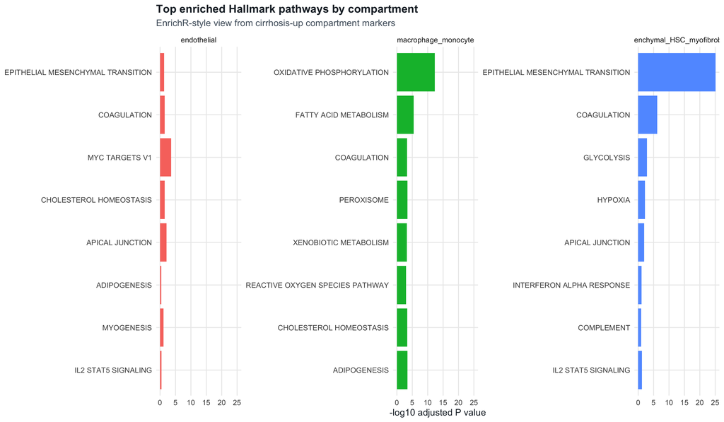

Figure: Enrichment strength by compartment. Longer bars indicate stronger adjusted enrichment. This view is useful for quickly seeing which mechanism themes dominate each disease-relevant compartment.

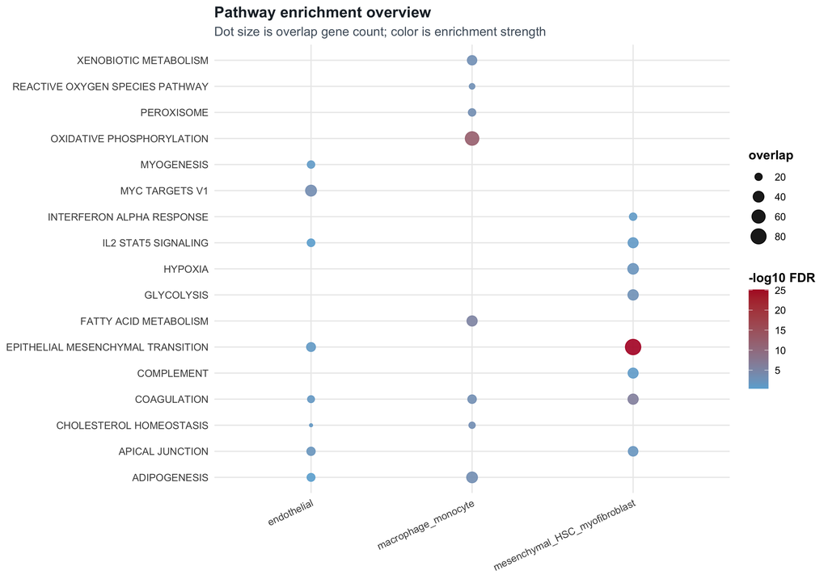

Figure: Pathway dot plot. Dot size is the number of overlapping significant genes. Color is the strength of enrichment. This makes it easier to compare both pathway strength and pathway gene support across compartments.

How to read the plots:

- The bar plot is an EnrichR-style view: longer bars mean stronger adjusted enrichment.
- The dot plot shows the same results across compartments: dot size is overlap gene count and color is `-log10(FDR)`.
- These plots show mechanism themes, not causal proof.

### pathfindR From Pseudobulk Signatures

pathfindR was added because the Hallmark table is a broad over-representation summary. It tells us which gene-set themes are enriched, but it does not ask whether the disease-associated genes form connected, active regions in a protein-interaction network. For target discovery, that matters. A connected collagen-processing or endothelial-interaction module is more biologically interpretable and experimentally actionable than a loose list of genes that happen to overlap a pathway.

The input to pathfindR is donor-level pseudobulk DE, not cell-level DE. For each refined cell state, the workflow uses significant genes in either direction at FDR < 0.05 and passes the signed log fold change into Reactome active-subnetwork enrichment. This keeps the mechanism analysis tied to donor-supported biology while still showing whether each term is supported by genes higher or lower in cirrhosis.

|  | label | n_input_genes | status | reason | gene_sets | p_val_threshold | enrichment_threshold | grSubNum |
| --- | --- | --- | --- | --- | --- | --- | --- | --- |
| 1 | HSC/myofibroblast | 247 | complete | 36 enriched Reactome terms returned. | Reactome | 0.05 | 0.1 | 100 |
| 2 | Endothelial | 284 | complete | 23 enriched Reactome terms returned. | Reactome | 0.05 | 0.1 | 100 |
| 3 | Macrophage reference-supported | 0 | not_run | Fewer than 10 significant donor-level pseudobulk genes at FDR &lt; 0.05. | Reactome | 0.05 | 0.1 | 100 |
| 4 | Macrophage marker-supported | 0 | not_run | Fewer than 10 significant donor-level pseudobulk genes at FDR &lt; 0.05. | Reactome | 0.05 | 0.1 | 100 |

The macrophage pseudobulk states are intentionally not forced through pathfindR in this compact run when they do not have enough significant donor-level genes at FDR < 0.05. That is a result, not a failure: macrophage communication and mechanism claims need a stronger macrophage-specific donor signal or an external macrophage atlas before being treated as pathway-level evidence.

|  | label | Term_Description | Fold_Enrichment | occurrence | support | lowest_p | n_up_genes | n_down_genes | Up_regulated | Down_regulated |
| --- | --- | --- | --- | --- | --- | --- | --- | --- | --- | --- |
| 1 | Endothelial | Trafficking and processing of endosomal TLR | 25.31132867132867 | 10 | 0.25 | 6.343692553307401e-07 | 0 | 4 |  | CTSB, CTSL, HSP90B1, LGMN |
| 2 | Endothelial | Interleukin-4 and Interleukin-13 signaling | 5.928779688779689 | 10 | 0.1 | 4.809705055519986e-05 | 3 | 5 | ANXA1, FN1, VIM | CD36, HIF1A, HSP90B1, IL13RA2, TIMP1 |
| 3 | Endothelial | Post-translational protein phosphorylation | 7.051012987012988 | 10 | 0.1 | 0.00464927643143121 | 6 | 3 | BMP4, EVA1A, FN1, LGALS1, SPARCL1, VWA1 | CSF1, HSP90B1, TIMP1 |
| 4 | Endothelial | Syndecan interactions | 12.18693602693603 | 10 | 0.1 | 0.00490697015198734 | 2 | 2 | FN1, ITGA2 | ITGB3, PRKCA |
| 5 | Endothelial | Extracellular matrix organization | 5.777585892368502 | 10 | 0.2 | 0.00633604006580572 | 7 | 14 | BMP4, CAPN11, COL21A1, EFEMP1, FN1, ITGA2, VWF | BMP2, COL10A1, CTSB, CTSD, CTSL, EMILIN1, ITGA9, ITGB3, KDR, NTN4, PRKCA, PXDN, TIMP1, TIMP2 |
| 6 | Endothelial | Regulation of Insulin-like Growth Factor (IGF) transport and uptake by Insulin-like Growth Factor Binding Proteins (IGFBPs) | 6.06849478390462 | 10 | 0.1 | 0.00971546624715456 | 6 | 3 | BMP4, EVA1A, FN1, LGALS1, SPARCL1, VWA1 | CSF1, HSP90B1, TIMP1 |
| 7 | Endothelial | Platelet activation, signaling and aggregation | 4.801273434736469 | 8 | 0.05 | 0.01054247767335427 | 3 | 12 | FN1, MGLL, VWF | CD36, CLEC1B, DGKG, ECM1, F2R, F8, ITGB3, LHFPL2, PCDH7, PRKCA, TIMP1, TIMP3 |
| 8 | Endothelial | Muscle contraction | 4.154637281910009 | 8 | 0.05 | 0.01374893825978803 | 2 | 8 | ANXA1, VIM | ATP1B1, ATP1B2, GATA4, HIPK2, KCNE3, NPR1, SLC8A1, SORBS1 |
| 9 | HSC/myofibroblast | Extracellular matrix organization | 11.71287835322763 | 10 | 0.5 | 1.463934321283502e-17 | 35 | 2 | ADAMTS2, COL14A1, COL15A1, COL1A1, COL1A2, COL3A1, COL5A1, COL5A2, COL8A1, COMP, CTSK, DCN, EFEMP1, EFEMP2, FBLN1, FBLN2, FBN1, FMOD, FN1, LAMB1, LOX, LOXL1, LOXL2, LTBP2, LUM, MFAP2, MMP2, PCOLCE, PE… | ITGA8, PDGFA |
| 10 | HSC/myofibroblast | Molecules associated with elastic fibres | 23.02363451317426 | 10 | 0.15 | 8.751639296472365e-13 | 8 | 1 | EFEMP1, EFEMP2, FBLN1, FBLN2, FBN1, FN1, LTBP2, MFAP2 | ITGA8 |

[output cut: 6 more lines]

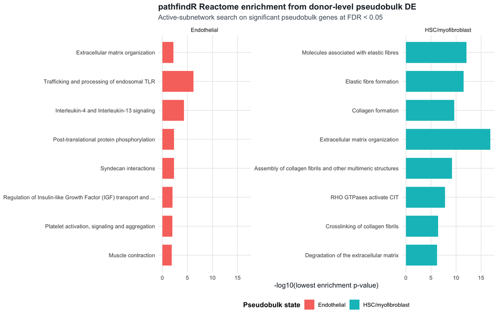

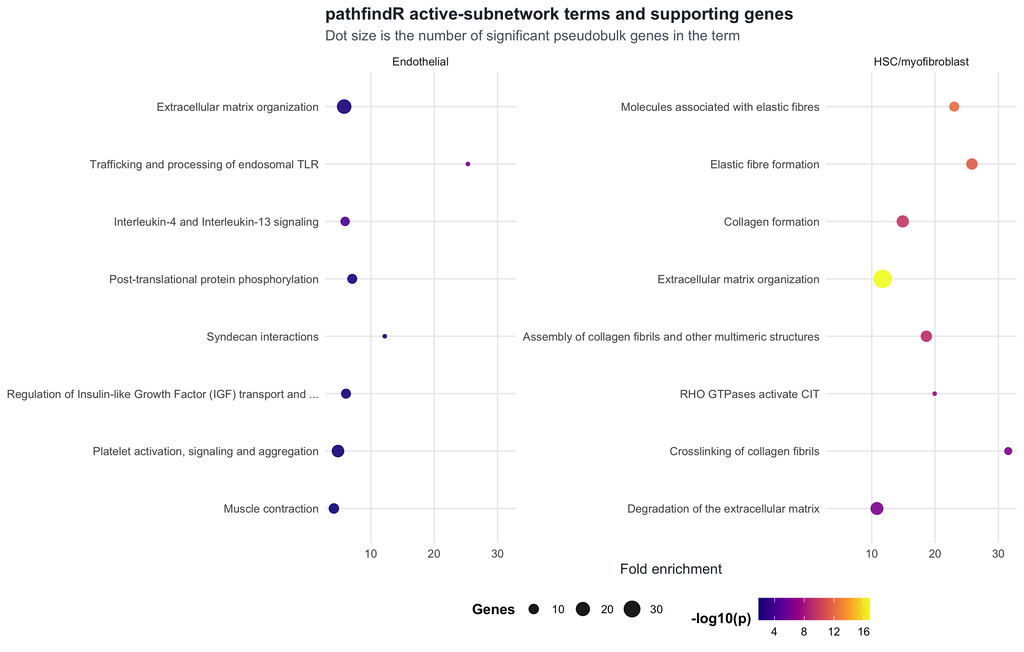

Figure: pathfindR active-subnetwork terms. Dot size is the number of significant donor-level genes in the term, and color is enrichment strength. This view helps distinguish a statistically enriched pathway with broad support from a pathway driven by only a few genes.

## Prioritization Score

The scoring model is rule-based because the donor count is small and transparency matters. It rewards disease biology, donor support, validation, modality, and conservation, while penalizing broad expression and safety risk.

Candidate-class guide:

| Class | Meaning | How to use it |
| --- | --- | --- |
| Diagnostic biomarker | A gene or protein that helps detect disease state or fibrosis burden | prioritize assayability, specificity, and validation across cohorts |
| Pharmacodynamic biomarker | A marker expected to move with treatment response | useful for early experiments and dose-response studies |
| Therapeutic target | A plausible intervention point with druggable biology | requires perturbation, safety, and tissue-selectivity evidence |
| Future validation marker | Biologically compelling but not ready for nomination | keep in validation queue, especially for spatial or macrophage-focused studies |

| component | direction | max_points | rationale |
| --- | --- | --- | --- |
| disease_association_points | positive | 20 | Rewards cirrhosis-up genes with meaningful effect size and adjusted significance, using donor-aware support when available. |
| donor_consistency_points | positive | 18 | Rewards signals that survive donor-level pseudobulk rather than only cell-level testing. |
| specificity_points | positive | 15 | Rewards a higher fraction of expressing cells in cirrhotic versus healthy cells inside the intended compartment. |
| pathway_points | positive | 14 | Rewards genes present in pathfindR Reactome active-subnetwork terms from donor-level pseudobulk signatures, with curated fibrosis mechanism support as fallback. |
| external_validation_points | positive | 18 | Rewards directionality in GSE244832, GSE207310, and mouse ortholog checks. |
| modality_points | positive | 10 | Rewards secreted, surface, receptor, enzyme, or otherwise assayable proteins. |
| conservation_points | positive | 6 | Rewards human-to-mouse orthology for preclinical feasibility. |
| safety_penalty | negative | -8 | Penalizes broad tissue expression, vascular or immune safety risk, pleiotropy, and direct targeting of structural matrix proteins. |
| blood_specificity_penalty | negative | -5 | Penalizes broad blood detectability unless the intended use is circulating injury or immune context. |
| therapeutic_penalty | negative | -4 | Penalizes therapeutic hypotheses with known clinical or on-target safety concerns. |

Guardrails:

- A gene receives pseudobulk credit only when support appears in its intended compartment.
- Blood detectability is penalized when it weakens tissue specificity.
- Vascular, immune, coagulation, broad stromal, and direct matrix-targeting risks are penalized.
- External validation includes GSE244832, GSE207310, blood specificity, and mouse ortholog checks.

|  | rank | gene | compartment | candidate_class | clinical_use_case | total_score | translational_nomination | nomination_caution |
| --- | --- | --- | --- | --- | --- | --- | --- | --- |
| 1 | 1 | COL1A1 | mesenchymal_HSC_myofibroblast | diagnostic biomarker | fibrosis burden and pharmacodynamic endpoint | 78.45 | fibrosis burden endpoint | standard orthogonal validation required |
| 2 | 2 | TIMP1 | mesenchymal_HSC_myofibroblast | pharmacodynamic biomarker | secreted pharmacodynamic marker with specificity caveat | 77.3887327317836 | near-term biomarker program | requires tissue-specificity and safety evaluation |
| 3 | 3 | ACKR1 | endothelial | future validation marker | spatial vascular and immune trafficking validation | 76.38 | vascular niche marker and spatial validation | standard orthogonal validation required |
| 4 | 4 | COL3A1 | mesenchymal_HSC_myofibroblast | diagnostic biomarker | fibrosis burden and pharmacodynamic endpoint | 75.88934314154638 | fibrosis burden endpoint | requires tissue-specificity and safety evaluation |
| 5 | 5 | SPP1 | macrophage_monocyte | future validation marker | macrophage-to-stromal mechanism follow-up | 75.78597320876713 | macrophage-state biology and pharmacodynamic validation | standard orthogonal validation required |
| 6 | 6 | PDGFRA | mesenchymal_HSC_myofibroblast | therapeutic target | stromal activation perturbation hypothesis | 75.73739657697844 | therapeutic hypothesis requiring safety-window validation | requires tissue-specificity and safety evaluation |
| 7 | 7 | PLVAP | endothelial | diagnostic biomarker | scar-associated vascular niche readout | 67.01708167102439 | vascular niche marker and spatial validation | requires tissue-specificity and safety evaluation |
| 8 | 8 | CD9 | macrophage_monocyte | pharmacodynamic biomarker | scar-associated macrophage pharmacodynamic readout | 65.81112053083551 | macrophage-state biology and pharmacodynamic validation | requires tissue-specificity and safety evaluation |
| 9 | 9 | TREM2 | macrophage_monocyte | future validation marker | macrophage state stratification and perturbation studies | 57.60562059195723 | macrophage-state biology and pharmacodynamic validation | standard orthogonal validation required |
| 10 | 10 | MMP2 | mesenchymal_HSC_myofibroblast | future validation marker | matrix remodeling mechanism | 51.69 | secondary evidence candidate | standard orthogonal validation required |

[output cut: 11 more lines]

## Validation

Validation is used here as an orthogonal support layer, not as a second discovery run. A candidate is considered supported when an independent dataset shows the same disease direction, the expected tissue or compartment context, and enough metadata clarity to trust the comparison.

| Dataset | What it validates | Metadata used | QC or harmonization note | Main limitation |
| --- | --- | --- | --- | --- |
| GSE244832 | MASH-relevant HSC/myofibroblast signal | source condition, cluster/cell annotation, candidate expression | gene symbols harmonized; focused HSC-like and related compartments summarized | validation object is processed, so this is expression validation rather than full raw reanalysis |
| GSE207310 | independent human NAFLD/NASH directionality | sample disease label, fibrosis grade, biopsy metadata | Ensembl IDs mapped to symbols; linear models run on gene-level expression | bulk RNA-seq cannot localize signal to a cell type |
| GSE136103 blood | circulating expression and tissue-specificity risk | blood library sample IDs and candidate expression | kept separate from liver discovery | does not validate liver fibrosis direction |
| GSE136103 mouse | ortholog conservation and preclinical directionality | mouse healthy/fibrotic liver labels and ortholog mapping | human genes mapped to mouse orthologs | only a small two-sample screen, not powered DE |

I did not integrate the validation datasets into the primary UMAP because that would mix different assays, processed objects, and biological contexts. The safer strategy is label harmonization at the gene, sample, disease-label, and compartment level, then directionality checks in each dataset. A larger production study should add pseudobulk PCA or correlation heatmaps across harmonized donor-level profiles, but those plots only help if the underlying metadata and assays are comparable.

### GSE244832: MASH/HSC Validation

GSE244832 adds the closest external validation for HSC/myofibroblast biology in metabolic steatohepatitis. The useful question is simple: do stromal candidates from cirrhotic liver also rise in HSC-like or scar-relevant compartments across NORMAL, NAFL, and NASH labels?

|  | gene | condition | cells | mean_norm_expression | pct_detected | nash_vs_normal_delta |
| --- | --- | --- | --- | --- | --- | --- |
| 1 | COL1A1 | NAFL | 3037 | 1.018365087329411 | 12.47942048073757 | 0.5415935260806682 |
| 2 | COL1A1 | NASH | 18562 | 1.26993702499186 | 16.22131235858205 | 0.5415935260806682 |
| 3 | COL1A1 | NORMAL | 4584 | 0.7283434989111915 | 9.053228621291447 | 0.5415935260806682 |
| 4 | COL3A1 | NAFL | 3037 | 1.555483558682977 | 19.03193941389529 | 0.7352320847928056 |
| 5 | COL3A1 | NASH | 18562 | 2.229050666968016 | 27.79334123478073 | 0.7352320847928056 |
| 6 | COL3A1 | NORMAL | 4584 | 1.493818582175211 | 18.32460732984293 | 0.7352320847928056 |
| 7 | PDGFRA | NAFL | 3037 | 0.4803707248078949 | 5.959828778399737 | 0.6273160783967993 |
| 8 | PDGFRA | NASH | 18562 | 0.9113205909645986 | 11.73364939122939 | 0.6273160783967993 |
| 9 | PDGFRA | NORMAL | 4584 | 0.2840045125677994 | 3.555846422338569 | 0.6273160783967993 |
| 10 | PDGFRB | NAFL | 3037 | 1.395925086616364 | 16.56239710240369 | 0.6044848068927144 |

[output cut: 8 more lines]

What was done:

- The processed validation matrix was prepared into local gene, cell, count, and metadata files.
- Candidate genes were harmonized by gene symbol.
- HSC-like clusters were identified from stromal, collagen, and PDGF receptor marker expression.
- Candidate expression was summarized by source condition and cluster.
- The QC focus was metadata completeness, gene-symbol recovery, cells per condition, and whether the expected HSC-like state could be recovered from marker expression.

The line plot is the primary view here because it shows direction across NORMAL, NAFL, and NASH labels directly.

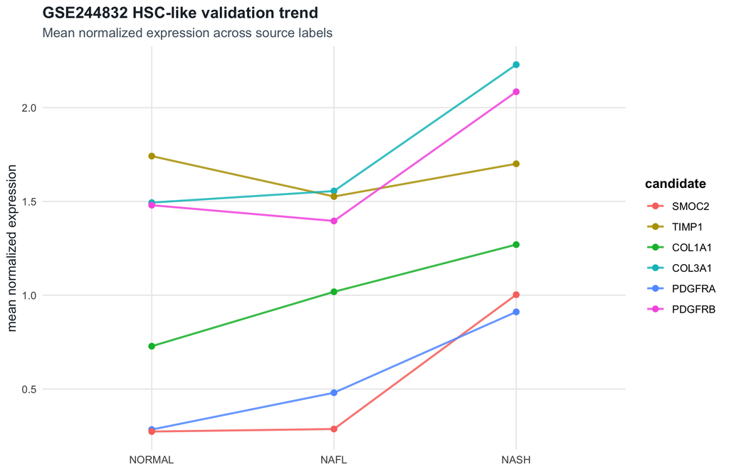

Figure: GSE244832 HSC-like validation trend. Lines track candidate expression across source conditions. A useful validation signal is not just high expression, but disease-relevant direction in the expected HSC/myofibroblast-like compartment.

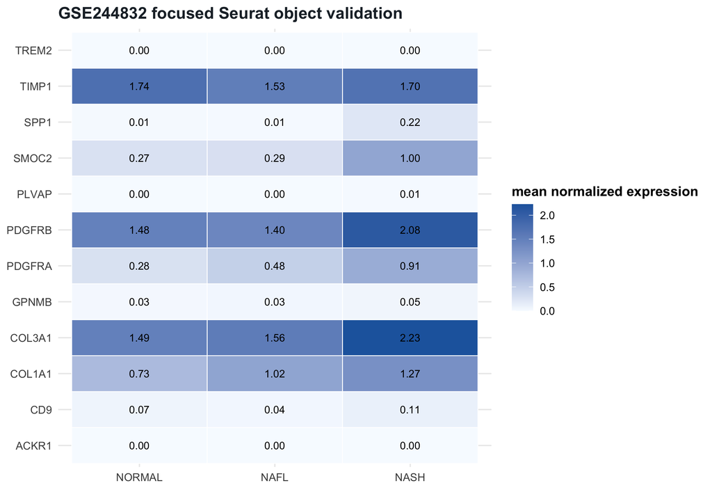

Figure: GSE244832 heatmap companion view. Rows are candidate genes, columns are source conditions or focused states, and color is mean normalized expression. This is useful for compact comparison, but the line plot above is easier for trend interpretation.

### GSE207310: Bulk NAFLD/NASH Directionality

GSE207310 provides independent bulk liver RNA-seq directionality. It asks whether the same candidates move in the expected direction in human NAFLD/NASH biopsies.

|  | gene | log2FC_NASH_vs_NAFL | p_value | p_adj | fibrosis_grade_log2FC_per_unit | fibrosis_p_value |
| --- | --- | --- | --- | --- | --- | --- |
| 1 | COL1A1 | 1.643581449393123 | 0.0002423638305066031 | 0.00180781100500248 | 0.2395272990142339 | 0.3762440828486101 |
| 2 | SMOC2 | 3.101909222197916 | 0.0003013018341670809 | 0.00180781100500248 | 0.08312266793392731 | 0.8723898387819334 |
| 3 | PLVAP | 1.08758897315546 | 0.00437859470462868 | 0.01500287554522673 | -0.02646547608697072 | 0.9120867755000512 |
| 4 | TIMP1 | 0.9607732946040468 | 0.00500095851507557 | 0.01500287554522673 | 0.1908743814877559 | 0.3783835554589449 |
| 5 | COL3A1 | 1.034151957483623 | 0.00854375462113569 | 0.02050501109072566 | 0.09566609269428318 | 0.7015958706162527 |
| 6 | TREM2 | 1.338496409786553 | 0.03958279109273448 | 0.0740469520360574 | 0.4292701212339473 | 0.3123006546314273 |
| 7 | SPP1 | 1.730387380540768 | 0.04319405535436682 | 0.0740469520360574 | 0.663881943296884 | 0.237002471154045 |
| 8 | PDGFRB | 0.4791755310157063 | 0.07511895732870547 | 0.1126784359930582 | 0.2549462053336364 | 0.1539321363338588 |
| 9 | PDGFRA | 0.5264025577906524 | 0.1134385797599136 | 0.1512514396798848 | -0.1000705233208193 | 0.64749434191432 |
| 10 | CD9 | 0.5236893754897483 | 0.1544391853524688 | 0.1853270224229626 | -0.05498665554793321 | 0.8207209395768854 |

[output cut: 2 more lines]

What was done:

- GEO phenotype metadata were parsed from the series matrix.
- Per-sample count files were read and mapped from Ensembl IDs to gene symbols.
- Candidate expression was modeled against NASH versus NAFL and fibrosis grade.
- The QC focus was sample label parsing, gene mapping success, disease-label balance, and whether candidate expression was present above background.

The bar plot is the primary view because it shows the NASH versus NAFL direction directly.

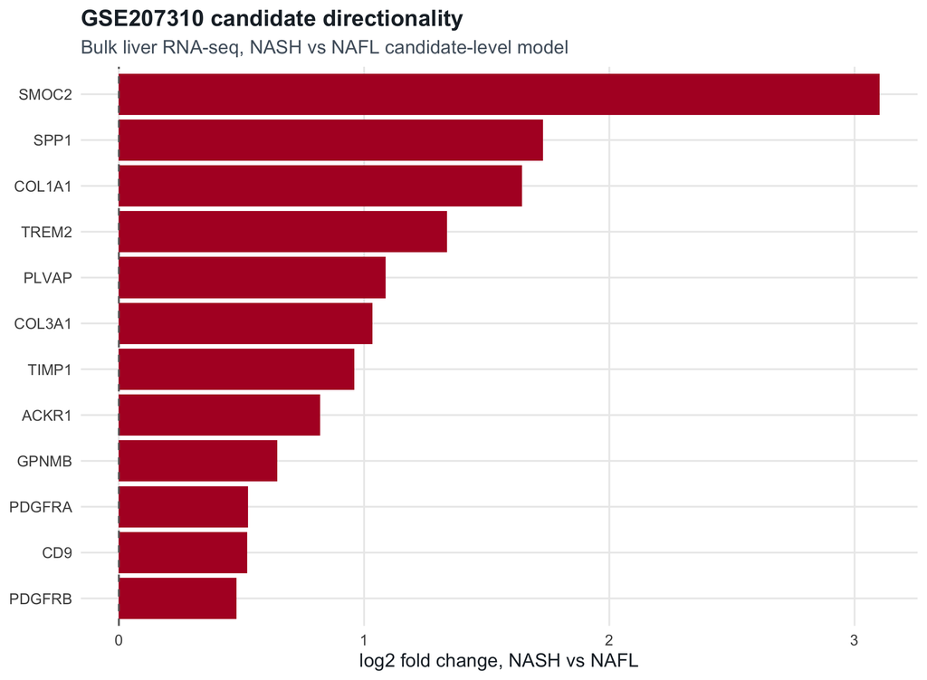

Figure: GSE207310 bulk directionality. Positive values indicate higher expression in NASH than NAFL. This supports disease direction, but it cannot localize the signal to a specific cell type.

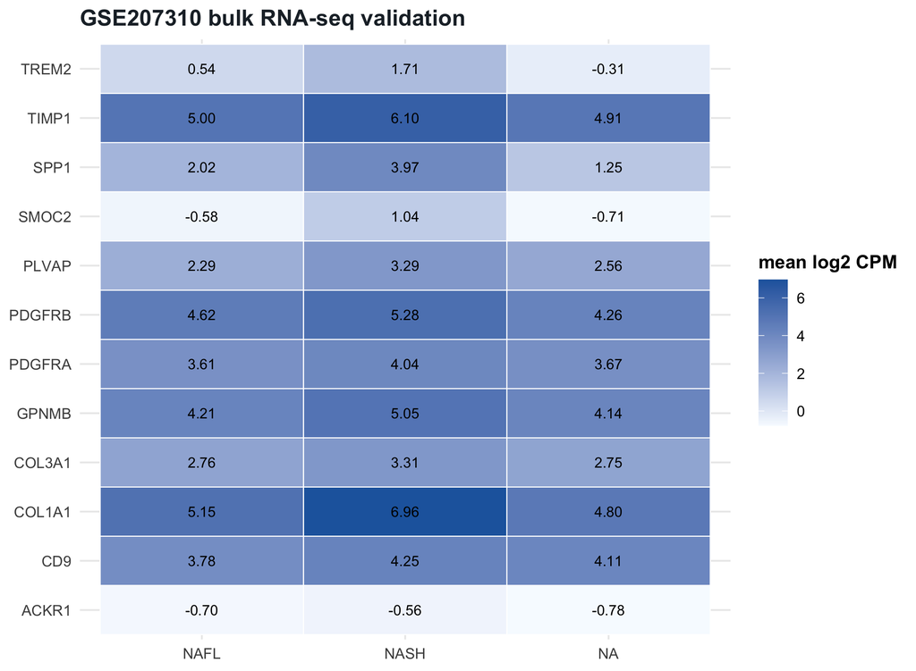

Figure: GSE207310 heatmap companion view. Rows are candidate genes, columns are disease labels, and color is mean log2 CPM. It is retained as a compact check, but the bar plot above is the clearer decision view.

Caution: bulk RNA-seq supports directionality but not cell of origin. It strengthens SMOC2, TIMP1, PLVAP, COL1A1, and COL3A1 as disease-linked signals, but single-cell or spatial validation is still needed to assign the signal to HSC, endothelial, or macrophage compartments.

### Blood And Mouse Secondary Validation

| validation_layer | samples | cells | role | main_caveat |
| --- | --- | --- | --- | --- |
| human_blood | 4 | 30764 | Checks whether candidate markers also appear in circulating immune cells or remain liver-niche biased. | Blood libraries do not define liver fibrosis state and are not used in the primary disease contrast. |
| mouse_liver | 2 | 5901 | Checks ortholog presence and fibrotic versus healthy directionality for preclinical model relevance. | Only one healthy and one fibrotic mouse sample are available, so this is a conservation screen, not inferential DE. |

Blood checks whether candidates are broadly detectable in circulation. Mouse checks ortholog conservation and fibrotic directionality.

|  | validation_role | gene | samples | mean_log_normalized_expression | mean_pct_detected |
| --- | --- | --- | --- | --- | --- |
| 1 | circulating_myeloid_context | LST1 | 4 | 1.334346319939968 | 55.48370969280478 |
| 2 | secreted_matrix_remodeling | TIMP1 | 4 | 0.6619917796061532 | 40.10181830337041 |
| 3 | macrophage_state_marker | CD9 | 4 | 0.03804812003933772 | 2.70135808148409 |
| 4 | macrophage_complement_context | C1QA | 4 | 0.0261102749922658 | 1.767840114506246 |
| 5 | stromal_receptor_target | PDGFRB | 4 | 0.00721030354941587 | 0.5147877528961029 |
| 6 | macrophage_complement_context | C1QB | 4 | 0.00513020028635932 | 0.3417686805349109 |
| 7 | macrophage_state_marker | GPNMB | 4 | 0.00356161683666843 | 0.2694783743257007 |
| 8 | scar_endothelial_marker | PLVAP | 4 | 0.00257216489108164 | 0.21862483537229 |
| 9 | macrophage_complement_context | C1QC | 4 | 0.00249505166254563 | 0.1670326563328864 |
| 10 | fibrosis_burden | COL1A1 | 4 | 0.0008068243074285524 | 0.05814926684975656 |

[output cut: 6 more lines]

|  | human_gene | mouse_gene | validation_role | fibrotic_vs_healthy_delta | pct_detected_delta | interpretation |
| --- | --- | --- | --- | --- | --- | --- |
| 1 | TREM2 | Trem2 | macrophage_state_marker | 0.9180965292056692 | 48.64724946724616 | higher in fibrotic mouse liver |
| 2 | C1QC | C1qc | macrophage_complement_context | 0.7435940826298564 | 13.29559732463544 | higher in fibrotic mouse liver |
| 3 | C1QA | C1qa | macrophage_complement_context | 0.6947114899647389 | 10.12194207376521 | higher in fibrotic mouse liver |
| 4 | GPNMB | Gpnmb | macrophage_state_marker | 0.6785372856391184 | 38.072117620047 | higher in fibrotic mouse liver |
| 5 | SPP1 | Spp1 | macrophage_state_marker | 0.6126669094633894 | 31.92837850155125 | higher in fibrotic mouse liver |
| 6 | C1QB | C1qb | macrophage_complement_context | 0.5920808492564977 | 5.935425735788712 | higher in fibrotic mouse liver |
| 7 | CD9 | Cd9 | macrophage_state_marker | 0.4026889783794687 | 16.83594412517034 | higher in fibrotic mouse liver |
| 8 | LST1 | Lst1 | circulating_myeloid_context | 0.385456155653737 | 11.17089312271625 | higher in fibrotic mouse liver |
| 9 | COL3A1 | Col3a1 | fibrosis_burden | 0.1579600541167971 | 11.66130355373055 | similar between mouse liver samples |
| 10 | TIMP1 | Timp1 | secreted_matrix_remodeling | 0.1175751513093222 | 8.709887703453122 | similar between mouse liver samples |

[output cut: 6 more lines]

How to read these validation tables:

- Blood table: higher percent detected means a candidate is more broadly visible in circulating cells. Broad blood signal can reduce tissue specificity.
- Mouse table: positive delta means the mouse ortholog is higher in fibrotic than healthy mouse liver.

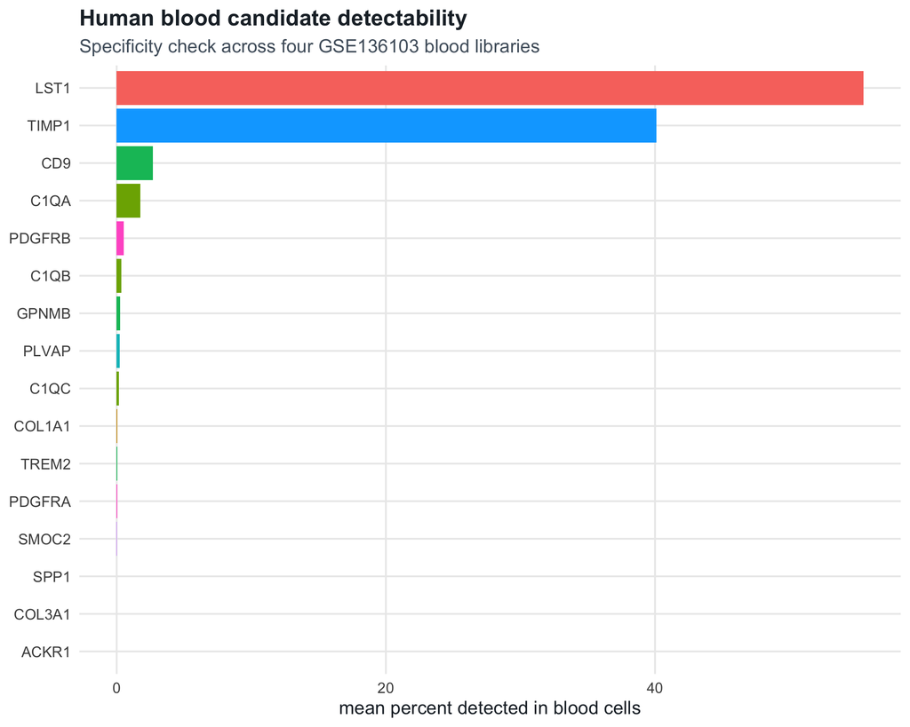

Figure: Blood detectability. Broad blood expression can be useful for a circulating assay, but it can also weaken tissue specificity for a liver-fibrosis marker.

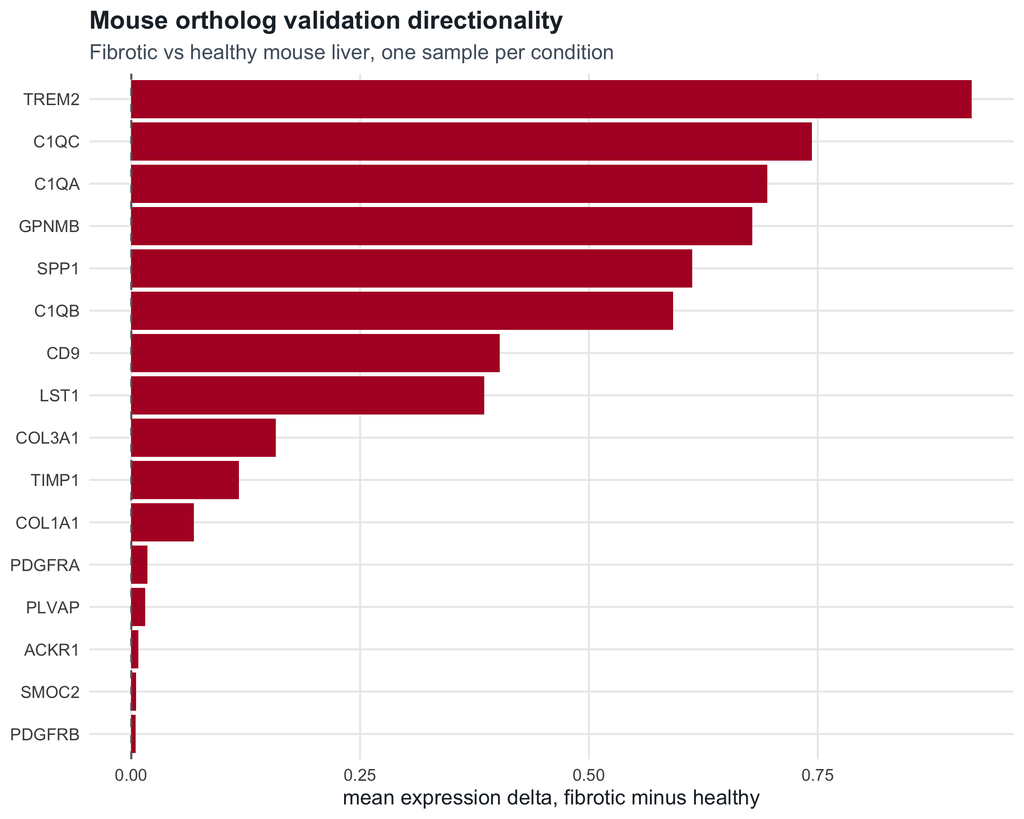

Figure: Mouse ortholog directionality. Positive values indicate higher expression in fibrotic mouse liver. This is a conservation screen, not a powered mouse differential-expression study.

Interpretation:

- TIMP1 and LST1 are detectable in blood, so they need context-aware interpretation.
- Most stromal, endothelial, and collagen candidates are low or absent in blood.
- Fibrotic mouse liver shows the strongest directionality for macrophage-state orthologs.
- Mouse stromal signal is present but weak in the two-sample screen.

## Translational Recommendation

The current MASH treatment landscape raises the bar. Resmetirom is approved for noncirrhotic NASH/MASH with F2-F3 fibrosis, and semaglutide is approved for MASH with moderate-to-advanced fibrosis. Late-stage FGF21 programs continue to move through MASH and compensated cirrhosis. At the same time, failures such as selonsertib and simtuzumab show why fibrosis programs need strong mechanism, patient selection, and pharmacodynamic biomarkers.

The ranked 10-20 candidate list is available in the hosted dashboard: [FibroTarget-Liver candidate table](https://caffeinated-code.shinyapps.io/fibrotarget-liver/). The same ranked evidence is stored in ranked_biomarker_target_candidates_translational.csv.

The best near-term strategy is:

1. **Biomarker track:** SMOC2, TIMP1, COL1A1, COL3A1, PLVAP, ACKR1.
2. **Stromal perturbation track:** PDGFRA and PDGFRB in HSC activation assays.
3. **Macrophage mechanism track:** TREM2, CD9, SPP1, GPNMB in a macrophage-focused atlas and spatial workflow.

Context from related MASH and fibrosis programs:

| Program | Company or lab | Target or mechanism | Relationship to this candidate list |
| --- | --- | --- | --- |
| Resmetirom/Rezdiffra | Madrigal Pharmaceuticals | THRB agonist | not one of the candidates; shows metabolic liver-directed therapy can change histology |
| Semaglutide/Wegovy | Novo Nordisk | GLP1R agonist biology | not one of the candidates; systemic metabolic treatment, useful comparator for endpoints |
| Pegozafermin | 89bio/Roche | FGF21 analog signaling through FGFR/KLB axis | not the same genes; relevant to metabolic-fibrotic trial context |
| Efruxifermin | Akero Therapeutics | FGF21 analog signaling through FGFR/KLB axis | not the same genes; relevant to compensated cirrhosis and MASH trial design |
| Selonsertib | Gilead Sciences | ASK1/MAP3K5 inhibitor | not one of the candidates; negative trial history argues for stronger pathway and patient-selection evidence |
| Simtuzumab | Gilead Sciences | LOXL2 antibody | adjacent matrix-remodeling biology; LOXL2 is in the broader scoring framework but not a top near-term nomination here |
| CM-101 | ChemomAb | CCL24 neutralizing antibody | not a direct candidate; conceptually related to chemokine and inflammatory fibrosis biology, including ACKR1 context |

## Infrastructure And Reproducibility

The repo includes local and cloud-facing execution paths. The local repo is designed for transparent review; `config/project.yaml` is the central project contract for paths, dataset roles, QC thresholds, disease contrast, key compartments, AWS placeholders, and scoring weights.

One-step local review run:

```bash
git clone https://github.com/Caffeinated-Code/FibroTarget_Liver.git
cd FibroTarget_Liver
make all
```

The `make all` target runs the full compact workflow in sequence:

```
check runtime
  -> fetch public data
  -> curate metadata
  -> run Seurat analysis and QC
  -> refine labels with the published reference
  -> run donor-level pseudobulk DE
  -> run pathfindR pathway analysis
  -> prioritize candidates
  -> run validation modules
  -> enrich translational evidence
  -> prepare dashboard data
  -> render reports
```

Individual components can also be run directly when reviewing or debugging:

```bash
make check
make fetch-data
make curate
make analyze
make refine-labels
make pseudobulk
make pathfindr
make prioritize
make validation
make hsc-validation
make gse244832-focused
make gse207310-validation
make secondary-validation
make evidence
make translational-evidence
make dashboard
make report
make render-summary
```

For a quick reproducibility smoke test without downloading the full public archive:

```bash
make nextflow-demo
```

| sample_id | cells | genes | total_counts | median_counts_per_cell | median_genes_per_cell | median_mito_percent | qc_pass_cells | metadata_rows | disease_states | compartments |
| --- | --- | --- | --- | --- | --- | --- | --- | --- | --- | --- |
| gse136103_demo | 480 | 14718 | 2390617 | 3722.5 | 1361 | 3.632326 | 480 | 480 | healthy;cirrhotic | endothelial;macrophage_monocyte;mesenchymal_HSC_myofibroblast;other_or_unresolved |

Core reproducibility pieces:

- Makefile: one-command local workflow targets.
- renv.lock: pinned R package environment.
- Dockerfile: container recipe for the R runtime and system libraries.
- Repository validator: checks required files and prevents private or large raw data from being tracked.
- Nextflow demo: local/AWS workflow contract test.

The Dockerfile provides a reproducible R environment for the analysis stack. It is meant to reduce setup differences across machines, especially for Seurat, tidyverse-style reporting, and system libraries needed by R packages.

The Nextflow demo reads a tracked GSE136103-derived 10x-style matrix, attaches metadata, summarizes QC and candidate-gene presence, runs a compact disease-direction screen on priority genes, creates PCA/UMAP-style review figures when the local R stack supports them, writes a ranked demo candidate table, and produces a Markdown report in `reports/nextflow_demo/`. It proves that the input/output contract works locally and can map to AWS Batch. It is intentionally small, but the stages mirror the production workflow: ingest, metadata check, QC, embedding, DE screen, pathway-style mechanism summary, candidate ranking, and report generation.

Current practical requirements:

| Run mode | Expected requirements | Typical use |
| --- | --- | --- |
| Review only | GitHub browser or local clone | inspect reports, figures, tables |
| Local Seurat workflow | R 4.6, Seurat 5.5, renv, several GB RAM, GEO archives | reproduce compact analysis |
| Dashboard | R, Shiny, DT, plotly | interactive result review |
| Nextflow demo | Java, Nextflow, small demo data | test workflow wiring |
| AWS production extension | S3, ECR, AWS Batch/ECS, CloudWatch, container image | scale proprietary or full validation datasets |

AWS mapping:

| Local concept | AWS production mapping |
| --- | --- |
| `data/raw`, `data/metadata` | S3 input prefixes |
| `reports`, `logs`, `dashboard/data` | S3 output prefixes |
| Dockerfile image | ECR image used by Nextflow processes |
| local Nextflow executor | AWS Batch executor |
| local logs | CloudWatch and Nextflow work directory logs |

Next infrastructure steps:

- Convert the demo into modular Nextflow processes for QC, annotation, pseudobulk, validation, and reporting.
- Add formal samplesheet schema validation.
- Add containerized CI on the demo dataset.
- Add AWS Batch documentation with IAM, S3 layout, ECR image, job queue, and logs.

## What Went Beyond The Assignment

Kept modest and practical:

- Interactive Shiny dashboard for UMAP, candidate classes, scoring, DE, validation, and QC review.
- Standalone Nextflow demo that runs locally on tracked demo data.
- AWS-ready Nextflow pattern using the same demo contract.

## Next Steps

1. Spatial validation for SMOC2, TIMP1, PLVAP, ACKR1, PDGFRA/B, and macrophage-state markers.
2. Full GSE244832 all-gene object reanalysis on AWS.
3. Macrophage-focused atlas validation for TREM2, CD9, SPP1, and GPNMB.
4. Full pathfindR term clustering and ReactomePA comparison module.
5. LIANA, NicheNet, or CellChat communication analysis with donor and receiver-response filters.
6. Perturbation assays before therapeutic nomination.

## References

- [Ramachandran et al., Nature 2019](https://www.nature.com/articles/s41586-019-1631-3)
- [Ramachandran Seurat object, Edinburgh DataShare](https://datashare.ed.ac.uk/handle/10283/3433)
- [UMAP, McInnes et al.](https://www.nature.com/articles/nbt.4314)
- [t-SNE for single-cell transcriptomics, Kobak and Berens](https://www.nature.com/articles/s41467-019-13056-x)
- [Single-cell best practices: integration](https://www.sc-best-practices.org/cellular_structure/integration)
- [dreamlet pseudobulk differential expression](https://pmc.ncbi.nlm.nih.gov/articles/PMC10187426/)
- [pathfindR](https://egeulgen.github.io/pathfindR/)
- [Human liver scRNA-seq and snRNA-seq comparison](https://pmc.ncbi.nlm.nih.gov/articles/PMC8948611/)
- [FDA Rezdiffra approval package](https://www.accessdata.fda.gov/drugsatfda_docs/nda/2024/217785Orig1s000Approv.pdf)
- [FDA Wegovy MASH approval](https://www.fda.gov/drugs/news-events-human-drugs/fda-approves-treatment-serious-liver-disease-known-mash)
- [Gilead STELLAR-3 selonsertib update](https://www.gilead.com/news/news-details/2019/gilead-announces-topline-data-from-phase-3-stellar-3-study-of-selonsertib-in-bridging-fibrosis-f3-due-to-nonalcoholic-steatohepatitis-nash)
- [Roche and 89bio pegozafermin announcement](https://www.roche.com/media/releases/med-cor-2025-09-18)